# final_project_dolgov

# Analysis of Faux Amis (False Cognates) translation quality in English-French Machine Translation

## Research objectives, hypotheses to be tested.

The main research objective of this study is finding the best machine translation model for English to French translation with an emphasis on false cognates.

I have been interested in this topic for as long as I have been learning languages - the translation of so-called “faux amis” or “false friends”. False cognates (or interlingual homonyms / paronyms) are words in two languages that are similar in spelling or pronunciation but different in meaning.

As language is an incredibly complex system that depends not only on its own internal rules but also on other languages, translation is a multifaceted and arduous endeavor. Despite their name, false friends do not help with this - on the contrary, they can lead to misunderstanding and incorrect translation of the text. In view of the fact that we are already seeing great development of machine translation systems, I believe it is important to study their ability to translate words that can easily mislead humans.

I have chosen MBart, NLLB and ALIGN as the machine translation models that will be used to compare translation quality. All three models can translate from English to French and vice versa.

### Hypotheses.

I have highlighted the following null hypothesis:

H0: The translation quality is independent of the model.

It holds because modern models trained on high-quality bilingual datasets may well have sufficient context awareness abilities to translate sentences correctly in spite of false cognates.

There are three alternative hypotheses:

H1: MBart has a higher translation quality.

H1: NLLB has a higher translation quality.

H1: ALIGN has a higher translation quality.

One hypothesis is allocated to each of the models, in case one shows better quality than the others. This is quite realistic, because datasets can differ in quality, size, and representation of “false friends”.

## Previous research.

The topic of false cognates, especially in the French-English language pair, is relatively underdeveloped.

The challenge of creating a dataset of interlingual paronyms in order to learn or improve machine translation models is addressed in the paper Challenge Dataset of Cognates and False Friend Pairs from Indian Languages [1], but, as is obvious from the title, only for Indian languages.

In their paper Automatic Identification of Cognates, False Friends, and Partial Cognates [2], the author proposes a standalone tool for automatic identification of “false friends”. The classifier was conceived to improve machine translation models and systems, and was designed for the French-English language pair.

However, the dataset that the authors used to train the classifier is not open to the public, and some of the references provided in the paper cannot be accessed.

## Description of the original dataset.

As there is no dataset focused specifically on false cognates in French and English in the public domain, I decided to create it myself. For this purpose, I defined a list of such word pairs and selected the most frequent ones (here the frequency is determined heuristically, based on many years of experience in learning both French and English on a high academic level). I parsed the specific pairs from several sites[3][4][5] listed at the end of the study, then hand-picked them. The final size of the dataset is 74 pairs of false cognates.

For each pair, I wrote four sentences:

- English sentence
- French translation
- French sentence
- English translation

Then, I scored each translation using two metrics, the normalized Levenshtein distance and the BLEU score. Levenshtein distance gives a general sense of the similarity of two strings, and BLEU shows the quality of the translation specifically.

The variables in the dataset are divided into two parts:

1. Data for translation:
- en_fa - “false friend” in English
- fr_fa - “false friend” in French
- mode - translation direction - EnFr | FrEn
- sent - original message (language depends on translation direction)
- trans - manually translated message
- trans_MBart - translation of the MBart model
- trans_NLLB - translation of the NLLB model
- trans_ALIGN - translation of the ALIGN model
- POSent - position of the false cognate in the sentence - “start” | “mid” | “end”
2. Metrics for evaluating machine translation:
- Levenshtein_MBart
- BLEU_MBart
- Levenshtein_NLLB
- BLEU_NLLB
- Levenshtein_ALIGN
- BLEU_ALIGN

All variables in the first part are categorical (string), in the second part they are numeric, floating point variables.

```r
library(tidyverse)
data <- read.csv("C:\\Users\\nikol\\OneDrive\\Desktop\\HSE_R\\FauxAmisR\\final_project_data_dolgov.csv")
summary(data)
```

```
##     en_fa              fr_fa               mode               sent
##  Length:148         Length:148         Length:148         Length:148
##  Class :character   Class :character   Class :character   Class :character
##  Mode  :character   Mode  :character   Mode  :character   Mode  :character
##
##
##
##     trans           trans_MBart         trans_NLLB        trans_ALIGN
##  Length:148         Length:148         Length:148         Length:148
##  Class :character   Class :character   Class :character   Class :character
##  Mode  :character   Mode  :character   Mode  :character   Mode  :character
##
##
##
##     POSent            BLEU_MBart       BLEU_NLLB        BLEU_ALIGN
##  Length:148         Min.   :0.0000   Min.   :0.0000   Min.   :0.0000
##  Class :character   1st Qu.:0.0000   1st Qu.:0.0000   1st Qu.:0.0000
##  Mode  :character   Median :0.4632   Median :0.5302   Median :0.5958
##                     Mean   :0.4297   Mean   :0.5344   Mean   :0.5593
##                     3rd Qu.:0.7655   3rd Qu.:1.0000   3rd Qu.:1.0000
##                     Max.   :1.0000   Max.   :1.0000   Max.   :1.0000
##  Levenshtein_MBart Levenshtein_NLLB Levenshtein_ALIGN
##  Min.   :0.00000   Min.   :0.0000   Min.   :0.0000
##  1st Qu.:0.07738   1st Qu.:0.0000   1st Qu.:0.0000
##  Median :0.19400   Median :0.1384   Median :0.1266
##  Mean   :0.23414   Mean   :0.1715   Mean   :0.1629
##  3rd Qu.:0.37424   3rd Qu.:0.2685   3rd Qu.:0.2585
##  Max.   :0.80000   Max.   :0.8163   Max.   :0.8163
```

```r
head(data)
```

```
##        en_fa        fr_fa mode
## 1 Accomodate    Accomoder EnFr
## 2    Account     Accompte EnFr
## 3   Actually Actuellement EnFr
## 4     Affair     Affaires EnFr
## 5     Agenda       Agenda EnFr
## 6        Arm         Arme EnFr
##                                                        sent
## 1              We cannot accomodate you at our hotel today.
## 2                                You have an empty account.
## 3             This is actually the best place in the world.
## 4                         Her husband was having an affair.
## 5 That is exactly their agenda - they want to make us fear.
## 6                               Arms crossed, he sat there.
##                                                               trans
```

[output cut: 41 more lines]

## Analysis Methods.

I will use the following methods to analyze the dataset:

- ANOVA tests, T-test (statistical analysis)
- histograms, boxplots, corellogram (visualization)

## Descriptive Statistics.

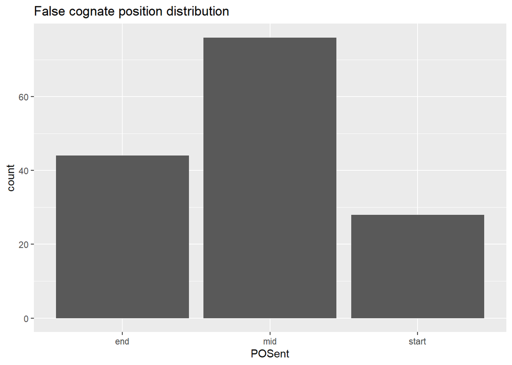

```r
library(ggplot2)

p <- data %>%
  ggplot(aes(x=POSent)) +
  geom_histogram(stat="count") +
  ggtitle('False cognate position distribution')
p
```

First, it is worth checking if there are empty elements in the dataset, or sentences that are much longer or shorter than others. Both of these criteria can affect the average quality of the translation.

```r
print(paste("Number of empty elements:", sum(is.na(data))))
```

```
## [1] "Number of empty elements: 0"
```

```r
props <- prop.table(table(data$mode))[1]
print(paste("Proportion of English to French sentences: ", props))
```

```
## [1] "Proportion of English to French sentences:  0.5"
```

```r
data$len_sent <- nchar(data$sent)
data$len_trans <- nchar(data$trans)

print(paste("Mean original sentence length: ", mean(data$len_sent)))
```

```
## [1] "Mean original sentence length:  40.8378378378378"
```

```r
print(paste("Mean original translation length: ", mean(data$len_trans)))
```

```
## [1] "Mean original translation length:  42.2364864864865"
```

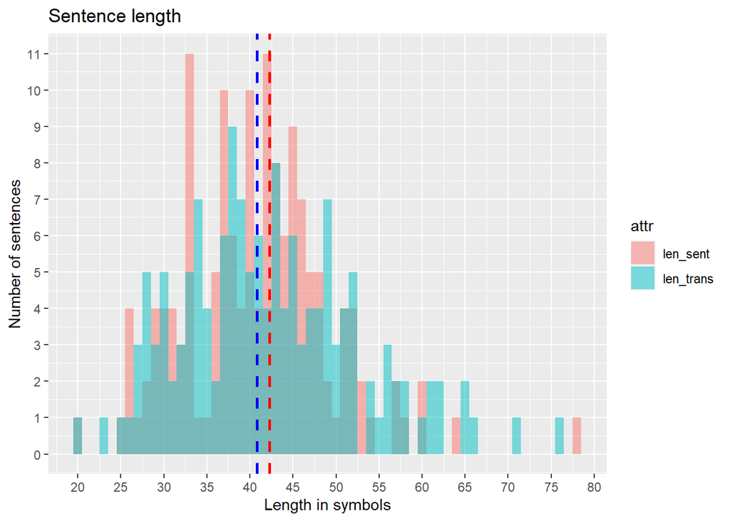

```r
hist_data <- data %>%
  pivot_longer(cols=(len_sent:len_trans), names_to="attr", values_to="length")

p <- hist_data %>%
  ggplot(aes(x=length, group=attr, fill=attr)) +
  geom_histogram(binwidth=1, alpha=0.5, position="identity") +
  scale_x_continuous(name = "Length in symbols",
                           breaks=seq(0, 80, 5)) +
        scale_y_continuous(name = "Number of sentences",
                           breaks=seq(0, 15, 1)) +
  ggtitle("Sentence length") +
  geom_vline(xintercept=mean(data$len_sent), size=1, colour="blue", linetype="dashed") +
  geom_vline(xintercept=mean(data$len_trans), size=1, colour="red", linetype="dashed")
p
```

The dataset does not contain any empty sentences or other empty variables, sentences are represented by a normal distribution of length of both original and translated sentences. The average length value is approximately 41 symbols.

The ratio of sentences in both languages is exactly 50%.